# py_sklearn_multiclass_kaggle_tabular_playground_2021dec

### Multi-Class Model for Kaggle Tabular Playground Series December 2021 Using Python and Scikit-Learn

### December 20, 2021

Template Credit: Adapted from a template made available by Dr. Jason Brownlee of Machine Learning Mastery. [https://machinelearningmastery.com/]

SUMMARY: This project aims to construct a predictive model using various machine learning algorithms and document the end-to-end steps using a template. The Kaggle Tabular Playground December 2021 dataset is a multi-class modeling situation where we attempt to predict one of several (more than two) possible outcomes.

INTRODUCTION: Kaggle wants to provide an approachable environment for relatively new people in their data science journey. Since January 2021, they have hosted playground-style competitions on Kaggle with fun but less complex, tabular datasets. The dataset used for this competition is synthetic but based on a real dataset and generated using a CTGAN. The dataset is used for this competition is synthetic, but based on a real dataset and generated using a CTGAN. This dataset is based off of the original Forest Cover Type Prediction competition.

ANALYSIS: The average performance of the machine learning algorithms achieved an accuracy benchmark of 0.9343 using the training dataset. Furthermore, we selected Random Forest as the final model as it processed the training dataset with a final accuracy score of 0.9581. When we processed the test dataset with the final model, the model achieved an accuracy score of 0.9513.

CONCLUSION: In this iteration, the Random Forest model appeared to be a suitable algorithm for modeling this dataset.

Dataset Used: Kaggle Tabular Playground 2021 December Data Set

Dataset ML Model: Multi-Class classification with numerical and categorical attributes

Dataset Reference: https://www.kaggle.com/c/tabular-playground-series-dec-2021

One potential source of performance benchmark: https://www.kaggle.com/c/tabular-playground-series-dec-2021/leaderboard

## Task 1 - Prepare Environment

```python
# Retrieve the CPU information
ncpu = !nproc
print("The number of available CPUs is:", ncpu[0])
```

```
The number of available CPUs is: 4
```

### 1.a) Load libraries and modules

```python
# Set the random seed number for reproducible results
RNG_SEED = 88
```

```python
import numpy as np
import pandas as pd
import seaborn as sns
import matplotlib.pyplot as plt
import os
import sys
import math
# import boto3
from datetime import datetime
from sklearn import preprocessing
from sklearn.model_selection import train_test_split
from sklearn.model_selection import StratifiedKFold
from sklearn.model_selection import cross_val_score
from sklearn.model_selection import GridSearchCV
from sklearn.metrics import classification_report
from sklearn.metrics import confusion_matrix
from sklearn.metrics import accuracy_score
from sklearn.pipeline import Pipeline
from sklearn import compose
from sklearn import impute

from sklearn.linear_model import LogisticRegression
from sklearn.discriminant_analysis import LinearDiscriminantAnalysis
from sklearn.tree import DecisionTreeClassifier
from sklearn.neighbors import KNeighborsClassifier
from sklearn.ensemble import BaggingClassifier
from sklearn.ensemble import RandomForestClassifier
from sklearn.ensemble import ExtraTreesClassifier
```

### 1.b) Set up the controlling parameters and functions

```python
# Begin the timer for the script processing
START_TIME_SCRIPT = datetime.now()
```

```python
# Set up the number of CPU cores available for multi-thread processing
N_JOBS = 2

# Set up the flag to stop sending progress emails (setting to True will send status emails!)
NOTIFY_STATUS = False

# Set the percentage sizes for splitting the dataset
TEST_SET_RATIO = 0.2
VAL_SET_RATIO = 0.2

# Set the number of folds for cross validation
N_FOLDS = 5

# Set various default modeling parameters
SCORING_METRIC = 'accuracy'

# Define the directory locations and file names
TRAIN_DATASET = 'train.csv'
TEST_DATASET = 'test.csv'
```

```python
# Set up the email notification function
def status_notify(msg_text):
    access_key = os.environ.get('SNS_ACCESS_KEY')
    secret_key = os.environ.get('SNS_SECRET_KEY')
    aws_region = os.environ.get('SNS_AWS_REGION')
    topic_arn = os.environ.get('SNS_TOPIC_ARN')
    if (access_key is None) or (secret_key is None) or (aws_region is None):
        sys.exit("Incomplete notification setup info. Script Processing Aborted!!!")
    sns = boto3.client('sns', aws_access_key_id=access_key, aws_secret_access_key=secret_key, region_name=aws_region)
    response = sns.publish(TopicArn=topic_arn, Message=msg_text)
    if response['ResponseMetadata']['HTTPStatusCode'] != 200 :
        print('Status notification not OK with HTTP status code:', response['ResponseMetadata']['HTTPStatusCode'])
```

```python
if NOTIFY_STATUS: status_notify("Task 1 - Prepare Environment has begun! " + datetime.now().strftime('%a %B %d, %Y %I:%M:%S %p'))
```

### 1.c) Load dataset

```python
if not os.path.exists(TRAIN_DATASET):
    !wget https://dainesanalytics.com/datasets/kaggle-tabular-playground-2021dec/train.csv
```

```python
df_dataset_import = pd.read_csv(TRAIN_DATASET, index_col=False)

# Take a peek at the dataframe after import
print(df_dataset_import.head())
```

```
   Id  Elevation  Aspect  Slope  Horizontal_Distance_To_Hydrology  \
0   0       3189      40      8                                30
1   1       3026     182      5                               280
2   2       3106      13      7                               351
3   3       3022     276     13                               192
4   4       2906     186     13                               266

   Vertical_Distance_To_Hydrology  Horizontal_Distance_To_Roadways  \
0                              13                             3270
1                              29                             3270
2                              37                             2914
3                              16                             3034
4                              22                             2916

   Hillshade_9am  Hillshade_Noon  Hillshade_3pm  ...  Soil_Type32  \
```

[output cut: 21 more lines]

```python
df_dataset_import.info(verbose=True)
```

```
<class 'pandas.core.frame.DataFrame'>
RangeIndex: 4000000 entries, 0 to 3999999
Data columns (total 56 columns):
 #   Column                              Dtype
---  ------                              -----
 0   Id                                  int64
 1   Elevation                           int64
 2   Aspect                              int64
 3   Slope                               int64
 4   Horizontal_Distance_To_Hydrology    int64
 5   Vertical_Distance_To_Hydrology      int64
 6   Horizontal_Distance_To_Roadways     int64
 7   Hillshade_9am                       int64
 8   Hillshade_Noon                      int64
 9   Hillshade_3pm                       int64
```

[output cut: 48 more lines]

```python
print(df_dataset_import.describe())
```

```
                 Id     Elevation        Aspect         Slope  \
count  4.000000e+06  4.000000e+06  4.000000e+06  4.000000e+06
mean   2.000000e+06  2.980192e+03  1.515857e+02  1.509754e+01
std    1.154701e+06  2.890482e+02  1.099611e+02  8.546731e+00
min    0.000000e+00  1.773000e+03 -3.300000e+01 -3.000000e+00
25%    9.999998e+05  2.760000e+03  6.000000e+01  9.000000e+00
50%    2.000000e+06  2.966000e+03  1.230000e+02  1.400000e+01
75%    2.999999e+06  3.217000e+03  2.470000e+02  2.000000e+01
max    3.999999e+06  4.383000e+03  4.070000e+02  6.400000e+01

       Horizontal_Distance_To_Hydrology  Vertical_Distance_To_Hydrology  \
count                      4.000000e+06                    4.000000e+06
mean                       2.713154e+02                    5.166262e+01
std                        2.265497e+02                    6.821597e+01
min                       -9.200000e+01                   -3.170000e+02
25%                        1.100000e+02                    4.000000e+00
50%                        2.130000e+02                    3.100000e+01
75%                        3.610000e+02                    7.800000e+01
max                        1.602000e+03                    6.470000e+02

       Horizontal_Distance_To_Roadways  Hillshade_9am  Hillshade_Noon  \
count                     4.000000e+06   4.000000e+06    4.000000e+06
mean                      1.766642e+03   2.118375e+02    2.210614e+02
std                       1.315610e+03   3.075996e+01    2.223134e+01
min                      -2.870000e+02  -4.000000e+00    4.900000e+01
25%                       8.220000e+02   1.980000e+02    2.100000e+02
50%                       1.436000e+03   2.180000e+02    2.240000e+02
75%                       2.365000e+03   2.330000e+02    2.370000e+02
max                       7.666000e+03   3.010000e+02    2.790000e+02

       Hillshade_3pm  ...   Soil_Type32   Soil_Type33   Soil_Type34  \
count   4.000000e+06  ...  4.000000e+06  4.000000e+06  4.000000e+06
mean    1.408109e+02  ...  3.746200e-02  3.782075e-02  1.199500e-02
std     4.369864e+01  ...  1.898910e-01  1.907625e-01  1.088629e-01
min    -5.300000e+01  ...  0.000000e+00  0.000000e+00  0.000000e+00
25%     1.150000e+02  ...  0.000000e+00  0.000000e+00  0.000000e+00
50%     1.420000e+02  ...  0.000000e+00  0.000000e+00  0.000000e+00
75%     1.690000e+02  ...  0.000000e+00  0.000000e+00  0.000000e+00
max     2.720000e+02  ...  1.000000e+00  1.000000e+00  1.000000e+00

        Soil_Type35   Soil_Type36   Soil_Type37   Soil_Type38   Soil_Type39  \
count  4.000000e+06  4.000000e+06  4.000000e+06  4.000000e+06  4.000000e+06
mean   1.605350e-02  1.071275e-02  1.220750e-02  4.075150e-02  3.923925e-02
std    1.256813e-01  1.029465e-01  1.098111e-01  1.977140e-01  1.941637e-01
min    0.000000e+00  0.000000e+00  0.000000e+00  0.000000e+00  0.000000e+00
25%    0.000000e+00  0.000000e+00  0.000000e+00  0.000000e+00  0.000000e+00
50%    0.000000e+00  0.000000e+00  0.000000e+00  0.000000e+00  0.000000e+00
75%    0.000000e+00  0.000000e+00  0.000000e+00  0.000000e+00  0.000000e+00
max    1.000000e+00  1.000000e+00  1.000000e+00  1.000000e+00  1.000000e+00

        Soil_Type40    Cover_Type
count  4.000000e+06  4.000000e+06
mean   3.161850e-02  1.771335e+00
std    1.749822e-01  8.938060e-01
min    0.000000e+00  1.000000e+00
25%    0.000000e+00  1.000000e+00
50%    0.000000e+00  2.000000e+00
75%    0.000000e+00  2.000000e+00
max    1.000000e+00  7.000000e+00

[8 rows x 56 columns]
```

```python
print(df_dataset_import.isnull().sum())
print('Total number of NaN in the dataframe: ', df_dataset_import.isnull().sum().sum())
```

```
Id                                    0
Elevation                             0
Aspect                                0
Slope                                 0
Horizontal_Distance_To_Hydrology      0
Vertical_Distance_To_Hydrology        0
Horizontal_Distance_To_Roadways       0
Hillshade_9am                         0
Hillshade_Noon                        0
Hillshade_3pm                         0
Horizontal_Distance_To_Fire_Points    0
Wilderness_Area1                      0
Wilderness_Area2                      0
Wilderness_Area3                      0
Wilderness_Area4                      0
Soil_Type1                            0
Soil_Type2                            0
Soil_Type3                            0
Soil_Type4                            0
Soil_Type5                            0
Soil_Type6                            0
Soil_Type7                            0
Soil_Type8                            0
Soil_Type9                            0
Soil_Type10                           0
Soil_Type11                           0
Soil_Type12                           0
Soil_Type13                           0
Soil_Type14                           0
Soil_Type15                           0
Soil_Type16                           0
Soil_Type17                           0
Soil_Type18                           0
Soil_Type19                           0
Soil_Type20                           0
Soil_Type21                           0
Soil_Type22                           0
Soil_Type23                           0
Soil_Type24                           0
Soil_Type25                           0
Soil_Type26                           0
Soil_Type27                           0
Soil_Type28                           0
Soil_Type29                           0
Soil_Type30                           0
Soil_Type31                           0
Soil_Type32                           0
Soil_Type33                           0
Soil_Type34                           0
Soil_Type35                           0
Soil_Type36                           0
Soil_Type37                           0
Soil_Type38                           0
Soil_Type39                           0
Soil_Type40                           0
Cover_Type                            0
dtype: int64
Total number of NaN in the dataframe:  0
```

```python
# Get grouping size for the target variable
print(df_dataset_import.groupby('Cover_Type').size())
```

```
Cover_Type
1    1468136
2    2262087
3     195712
4        377
5          1
6      11426
7      62261
dtype: int64
```

### 1.d) Data Cleaning

```python
# Dropping features withunique values or no variations
df_dataset_import.drop(columns=['Id','Soil_Type7','Soil_Type15'], inplace=True)

#Dropping class with the least number of rows associated with
df_dataset_import = df_dataset_import[df_dataset_import['Cover_Type'] != 5]

# Convert columns from one data type to another
float_feature_list = ['Elevation','Aspect','Slope','Horizontal_Distance_To_Hydrology',
                      'Vertical_Distance_To_Hydrology','Horizontal_Distance_To_Roadways',
                      'Hillshade_9am','Hillshade_Noon','Hillshade_3pm','Horizontal_Distance_To_Fire_Points']
for feature in float_feature_list:
    df_dataset_import[feature] = df_dataset_import[feature].astype('float')

# Standardize the class column to the name of target
df_dataset_import = df_dataset_import.rename(columns={'Cover_Type':'target'})

# Take a peek at the dataframe after cleaning
print(df_dataset_import.head())
```

```
   Elevation  Aspect  Slope  Horizontal_Distance_To_Hydrology  \
0     3189.0    40.0    8.0                              30.0
1     3026.0   182.0    5.0                             280.0
2     3106.0    13.0    7.0                             351.0
3     3022.0   276.0   13.0                             192.0
4     2906.0   186.0   13.0                             266.0

   Vertical_Distance_To_Hydrology  Horizontal_Distance_To_Roadways  \
0                            13.0                           3270.0
1                            29.0                           3270.0
2                            37.0                           2914.0
3                            16.0                           3034.0
4                            22.0                           2916.0

   Hillshade_9am  Hillshade_Noon  Hillshade_3pm  \
```

[output cut: 28 more lines]

```python
df_dataset_import.info(verbose=True)
```

```
<class 'pandas.core.frame.DataFrame'>
Int64Index: 3999999 entries, 0 to 3999999
Data columns (total 53 columns):
 #   Column                              Dtype
---  ------                              -----
 0   Elevation                           float64
 1   Aspect                              float64
 2   Slope                               float64
 3   Horizontal_Distance_To_Hydrology    float64
 4   Vertical_Distance_To_Hydrology      float64
 5   Horizontal_Distance_To_Roadways     float64
 6   Hillshade_9am                       float64
 7   Hillshade_Noon                      float64
 8   Hillshade_3pm                       float64
 9   Horizontal_Distance_To_Fire_Points  float64
```

[output cut: 45 more lines]

```python
print(df_dataset_import.describe())
```

```
          Elevation        Aspect         Slope  \
count  3.999999e+06  3.999999e+06  3.999999e+06
mean   2.980192e+03  1.515857e+02  1.509753e+01
std    2.890482e+02  1.099611e+02  8.546724e+00
min    1.773000e+03 -3.300000e+01 -3.000000e+00
25%    2.760000e+03  6.000000e+01  9.000000e+00
50%    2.966000e+03  1.230000e+02  1.400000e+01
75%    3.217000e+03  2.470000e+02  2.000000e+01
max    4.383000e+03  4.070000e+02  6.400000e+01

       Horizontal_Distance_To_Hydrology  Vertical_Distance_To_Hydrology  \
count                      3.999999e+06                    3.999999e+06
mean                       2.713155e+02                    5.166261e+01
std                        2.265497e+02                    6.821597e+01
min                       -9.200000e+01                   -3.170000e+02
25%                        1.100000e+02                    4.000000e+00
50%                        2.130000e+02                    3.100000e+01
75%                        3.610000e+02                    7.800000e+01
max                        1.602000e+03                    6.470000e+02

       Horizontal_Distance_To_Roadways  Hillshade_9am  Hillshade_Noon  \
count                     3.999999e+06   3.999999e+06    3.999999e+06
mean                      1.766642e+03   2.118375e+02    2.210614e+02
std                       1.315610e+03   3.075996e+01    2.223134e+01
min                      -2.870000e+02  -4.000000e+00    4.900000e+01
25%                       8.220000e+02   1.980000e+02    2.100000e+02
50%                       1.436000e+03   2.180000e+02    2.240000e+02
75%                       2.365000e+03   2.330000e+02    2.370000e+02
max                       7.666000e+03   3.010000e+02    2.790000e+02

       Hillshade_3pm  Horizontal_Distance_To_Fire_Points  ...   Soil_Type32  \
count   3.999999e+06                        3.999999e+06  ...  3.999999e+06
mean    1.408109e+02                        1.581405e+03  ...  3.746201e-02
std     4.369864e+01                        1.127612e+03  ...  1.898911e-01
min    -5.300000e+01                       -2.770000e+02  ...  0.000000e+00
25%     1.150000e+02                        7.810000e+02  ...  0.000000e+00
50%     1.420000e+02                        1.361000e+03  ...  0.000000e+00
75%     1.690000e+02                        2.084000e+03  ...  0.000000e+00
max     2.720000e+02                        8.075000e+03  ...  1.000000e+00

        Soil_Type33   Soil_Type34   Soil_Type35   Soil_Type36   Soil_Type37  \
count  3.999999e+06  3.999999e+06  3.999999e+06  3.999999e+06  3.999999e+06
mean   3.782076e-02  1.199500e-02  1.605350e-02  1.071275e-02  1.220750e-02
std    1.907626e-01  1.088629e-01  1.256813e-01  1.029466e-01  1.098111e-01
min    0.000000e+00  0.000000e+00  0.000000e+00  0.000000e+00  0.000000e+00
25%    0.000000e+00  0.000000e+00  0.000000e+00  0.000000e+00  0.000000e+00
50%    0.000000e+00  0.000000e+00  0.000000e+00  0.000000e+00  0.000000e+00
75%    0.000000e+00  0.000000e+00  0.000000e+00  0.000000e+00  0.000000e+00
max    1.000000e+00  1.000000e+00  1.000000e+00  1.000000e+00  1.000000e+00

        Soil_Type38   Soil_Type39   Soil_Type40        target
count  3.999999e+06  3.999999e+06  3.999999e+06  3.999999e+06
mean   4.075151e-02  3.923926e-02  3.161851e-02  1.771335e+00
std    1.977140e-01  1.941637e-01  1.749822e-01  8.938047e-01
min    0.000000e+00  0.000000e+00  0.000000e+00  1.000000e+00
25%    0.000000e+00  0.000000e+00  0.000000e+00  1.000000e+00
50%    0.000000e+00  0.000000e+00  0.000000e+00  2.000000e+00
75%    0.000000e+00  0.000000e+00  0.000000e+00  2.000000e+00
max    1.000000e+00  1.000000e+00  1.000000e+00  7.000000e+00

[8 rows x 53 columns]
```

```python
print(df_dataset_import.isnull().sum())
print('Total number of NaN in the dataframe: ', df_dataset_import.isnull().sum().sum())
```

```
Elevation                             0
Aspect                                0
Slope                                 0
Horizontal_Distance_To_Hydrology      0
Vertical_Distance_To_Hydrology        0
Horizontal_Distance_To_Roadways       0
Hillshade_9am                         0
Hillshade_Noon                        0
Hillshade_3pm                         0
Horizontal_Distance_To_Fire_Points    0
Wilderness_Area1                      0
Wilderness_Area2                      0
Wilderness_Area3                      0
Wilderness_Area4                      0
Soil_Type1                            0
Soil_Type2                            0
Soil_Type3                            0
Soil_Type4                            0
Soil_Type5                            0
Soil_Type6                            0
Soil_Type8                            0
Soil_Type9                            0
Soil_Type10                           0
Soil_Type11                           0
Soil_Type12                           0
Soil_Type13                           0
Soil_Type14                           0
Soil_Type16                           0
Soil_Type17                           0
Soil_Type18                           0
Soil_Type19                           0
Soil_Type20                           0
Soil_Type21                           0
Soil_Type22                           0
Soil_Type23                           0
Soil_Type24                           0
Soil_Type25                           0
Soil_Type26                           0
Soil_Type27                           0
Soil_Type28                           0
Soil_Type29                           0
Soil_Type30                           0
Soil_Type31                           0
Soil_Type32                           0
Soil_Type33                           0
Soil_Type34                           0
Soil_Type35                           0
Soil_Type36                           0
Soil_Type37                           0
Soil_Type38                           0
Soil_Type39                           0
Soil_Type40                           0
target                                0
dtype: int64
Total number of NaN in the dataframe:  0
```

```python
# Get grouping size for the target variable
print(df_dataset_import.groupby('target').size())
```

```
target
1    1468136
2    2262087
3     195712
4        377
6      11426
7      62261
dtype: int64
```

### 1.e) Splitting Data into Sets

```python
# Use variable total_column_count to hold the number of columns in the dataframe
total_column_count = len(df_dataset_import.columns)

# Set up variable total_feature_count for the total number of attribute columns
total_feature_count = total_column_count-1

# We create attribute-only and target-only datasets (df_features_train and df_target_train)
df_target_train = df_dataset_import['target']
df_features_train = df_dataset_import.drop(['target'], axis=1)

print("df_dataset_import.shape: {} df_features_train.shape: {} df_target_train.shape: {}".format(df_dataset_import.shape, df_features_train.shape, df_target_train.shape))
```

```
df_dataset_import.shape: (3999999, 53) df_features_train.shape: (3999999, 52) df_target_train.shape: (3999999,)
```

### 1.f) Set up the parameters for data visualization

```python
# Set up the number of row and columns for visualization display. display_rows * display_columns should be >= total_feature_count
display_columns = 4
if total_feature_count % display_columns == 0 :
    display_rows = total_feature_count // display_columns
else :
    display_rows = (total_feature_count // display_columns) + 1

# Set figure width to display the data visualization plots
fig_size = plt.rcParams["figure.figsize"]
fig_size[0] = display_columns * 4
fig_size[1] = display_rows * 4
plt.rcParams["figure.figsize"] = fig_size
```

```python
if NOTIFY_STATUS: status_notify("Task 1 - Prepare Environment completed! " + datetime.now().strftime('%a %B %d, %Y %I:%M:%S %p'))
```

## Task 2 - Summarize and Visualize Data

```python
if NOTIFY_STATUS: status_notify("Task 2 - Summarize and Visualize Data has begun! " + datetime.now().strftime('%a %B %d, %Y %I:%M:%S %p'))
```

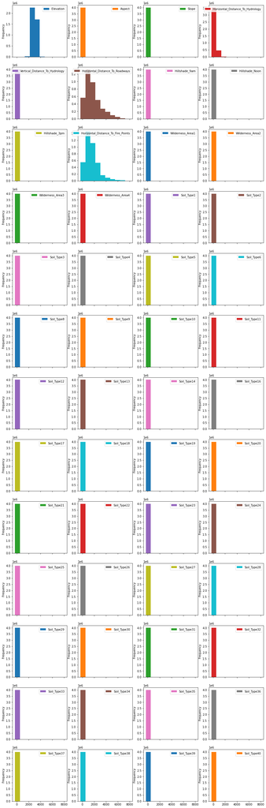

```python
# Histograms for each attribute
df_features_train.plot(kind='hist', subplots=True, layout=(display_rows, display_columns))
plt.show()
```

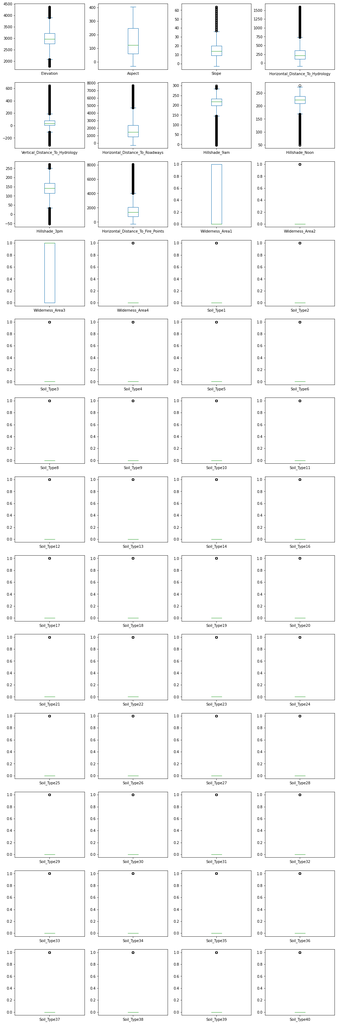

```python
# Box and Whisker plot for each attribute
df_features_train.plot(kind='box', subplots=True, layout=(display_rows, display_columns))
plt.show()
```

```python
# # Correlation matrix
# fig = plt.figure(figsize=(20,20))
# ax = fig.add_subplot(111)
# correlations = df_features_train.corr(method='pearson')
# cax = ax.matshow(correlations, vmin=-1, vmax=1)
# fig.colorbar(cax)
# plt.show()
```

```python
if NOTIFY_STATUS: status_notify("Task 2 - Summarize and Visualize Data completed! " + datetime.now().strftime('%a %B %d, %Y %I:%M:%S %p'))
```

## Task 3 - Pre-process Data

```python
if NOTIFY_STATUS: status_notify("Task 3 - Pre-process Data has begun! " + datetime.now().strftime('%a %B %d, %Y %I:%M:%S %p'))
```

### 3.a) Feature Scaling

```python
# Compose pipeline for the numerical and categorical features (Block #1 of 2)
numeric_columns = df_features_train.select_dtypes(include=['float64']).columns
numeric_transformer = Pipeline(steps=[
    ('imputer', impute.SimpleImputer(strategy="constant", fill_value=0)),
    ('scaler', preprocessing.MinMaxScaler())
])
categorical_columns = df_features_train.select_dtypes(include=['object','bool','category']).columns
categorical_transformer = Pipeline(steps=[
    ('imputer', impute.SimpleImputer(strategy='constant', fill_value='UKNOWN')),
    ('onehot', preprocessing.OneHotEncoder(sparse=False, handle_unknown='ignore'))
])

print("Number of numerical columns:", len(numeric_columns))
print("Number of categorical columns:", len(categorical_columns))
print("Total number of columns in the feature dataframe:", df_features_train.shape[1])
```

```
Number of numerical columns: 10
Number of categorical columns: 0
Total number of columns in the feature dataframe: 52
```

```python
# Compose pipeline for the numerical and categorical features (Block #2 of 2)
preprocessor = compose.ColumnTransformer(transformers=[
    ('num', numeric_transformer, numeric_columns),
    ('cat', categorical_transformer, categorical_columns)
], remainder='passthrough')

# Display the shapes of the training dataset for final inspection
array_features_train = preprocessor.fit_transform(df_features_train)
print("Transformed features from df_features_train.shape: {} to array_features_train.shape: {}".format(df_features_train.shape, array_features_train.shape))
```

```
Transformed features from df_features_train.shape: (3999999, 52) to array_features_train.shape: (3999999, 52)
```

### 3.b) Training Data Balancing

```python
# Not applicable for this iteration of the project
```

### 3.c) Feature Selection

```python
# Not applicable for this iteration of the project
```

### 3.d) Display the Final Datasets for Model-Building

```python
# Finalize the training dataset for the modeling activities
# array_features_train = df_features_train.to_numpy()
# array_target_train = df_target_train.ravel()
label_encoder = preprocessing.LabelEncoder()
array_target_train = label_encoder.fit_transform(df_target_train)
print("array_features_train.shape: {} array_target_train.shape: {}".format(array_features_train.shape, array_target_train.shape))
```

```
array_features_train.shape: (3999999, 52) array_target_train.shape: (3999999,)
```

```python
if NOTIFY_STATUS: status_notify("Task 3 - Pre-process Data completed! " + datetime.now().strftime('%a %B %d, %Y %I:%M:%S %p'))
```

## Task 4 - Train and Tune Models

```python
if NOTIFY_STATUS: status_notify("Task 4 - Train and Tune Models has begun! " + datetime.now().strftime('%a %B %d, %Y %I:%M:%S %p'))
```

### 4.a) Set test options and evaluation metric

```python
# Set up Algorithms Spot-Checking Array
start_time_training = datetime.now()
train_models = []
train_results = []
train_model_names = []
train_metrics = []
```

```python
train_models.append(('LGR', LogisticRegression(random_state=RNG_SEED, n_jobs=N_JOBS, solver='saga')))
train_models.append(('LDA', LinearDiscriminantAnalysis()))
train_models.append(('CART', DecisionTreeClassifier(random_state=RNG_SEED)))
# train_models.append(('KNN', KNeighborsClassifier(n_jobs=N_JOBS)))
train_models.append(('BGT', BaggingClassifier(random_state=RNG_SEED, n_jobs=N_JOBS)))
train_models.append(('RNF', RandomForestClassifier(random_state=RNG_SEED, n_jobs=N_JOBS)))
train_models.append(('EXT', ExtraTreesClassifier(random_state=RNG_SEED, n_jobs=N_JOBS)))
```

```python
# Generate model in turn
for name, model in train_models:
    if NOTIFY_STATUS: status_notify("Algorithm " + name + " modeling has begun! " + datetime.now().strftime('%a %B %d, %Y %I:%M:%S %p'))
    start_time_module = datetime.now()
    kfold = StratifiedKFold(n_splits=N_FOLDS, shuffle=True, random_state=RNG_SEED)
    cv_results = cross_val_score(model, array_features_train, array_target_train, cv=kfold, scoring=SCORING_METRIC, n_jobs=N_JOBS, verbose=1)
    train_results.append(cv_results)
    train_model_names.append(name)
    train_metrics.append(cv_results.mean())
    print("%s: %f (%f)" % (name, cv_results.mean(), cv_results.std()))
    print(model)
    print ('Model training time:', (datetime.now() - start_time_module), '\n')
    if NOTIFY_STATUS: status_notify("Algorithm " + name + " modeling completed! " + datetime.now().strftime('%a %B %d, %Y %I:%M:%S %p'))
print ('Average metrics (' + SCORING_METRIC + ') from all models:',np.mean(train_metrics))
print ('Total training time for all models:',(datetime.now() - start_time_training))
```

```
[Parallel(n_jobs=2)]: Using backend LokyBackend with 2 concurrent workers.
[Parallel(n_jobs=2)]: Done   5 out of   5 | elapsed: 53.7min finished
[Parallel(n_jobs=2)]: Using backend LokyBackend with 2 concurrent workers.
```

```
LGR: 0.917120 (0.000109)
LogisticRegression(n_jobs=2, random_state=88, solver='saga')
Model training time: 0:53:40.370511
```

```
[Parallel(n_jobs=2)]: Done   5 out of   5 | elapsed:  4.2min finished
[Parallel(n_jobs=2)]: Using backend LokyBackend with 2 concurrent workers.
```

```
LDA: 0.878341 (0.000101)
LinearDiscriminantAnalysis()
Model training time: 0:04:12.426224
```

```
[Parallel(n_jobs=2)]: Done   5 out of   5 | elapsed:  9.9min finished
[Parallel(n_jobs=2)]: Using backend LokyBackend with 2 concurrent workers.
```

```
CART: 0.942962 (0.000308)
DecisionTreeClassifier(random_state=88)
Model training time: 0:09:51.331766
```

```
[Parallel(n_jobs=2)]: Done   5 out of   5 | elapsed: 36.0min finished
[Parallel(n_jobs=2)]: Using backend LokyBackend with 2 concurrent workers.
```

```
BGT: 0.955037 (0.000193)
BaggingClassifier(n_jobs=2, random_state=88)
Model training time: 0:36:01.233563
```

```
[Parallel(n_jobs=2)]: Done   5 out of   5 | elapsed: 74.7min finished
[Parallel(n_jobs=2)]: Using backend LokyBackend with 2 concurrent workers.
```

```
RNF: 0.957732 (0.000114)
RandomForestClassifier(n_jobs=2, random_state=88)
Model training time: 1:14:42.599392

EXT: 0.955053 (0.000112)
ExtraTreesClassifier(n_jobs=2, random_state=88)
Model training time: 1:03:15.636468

Average metrics (accuracy) from all models: 0.9343744419268023
Total training time for all models: 4:01:43.637749
```

```
[Parallel(n_jobs=2)]: Done   5 out of   5 | elapsed: 63.3min finished
```

### 4.b) Spot-checking baseline algorithms

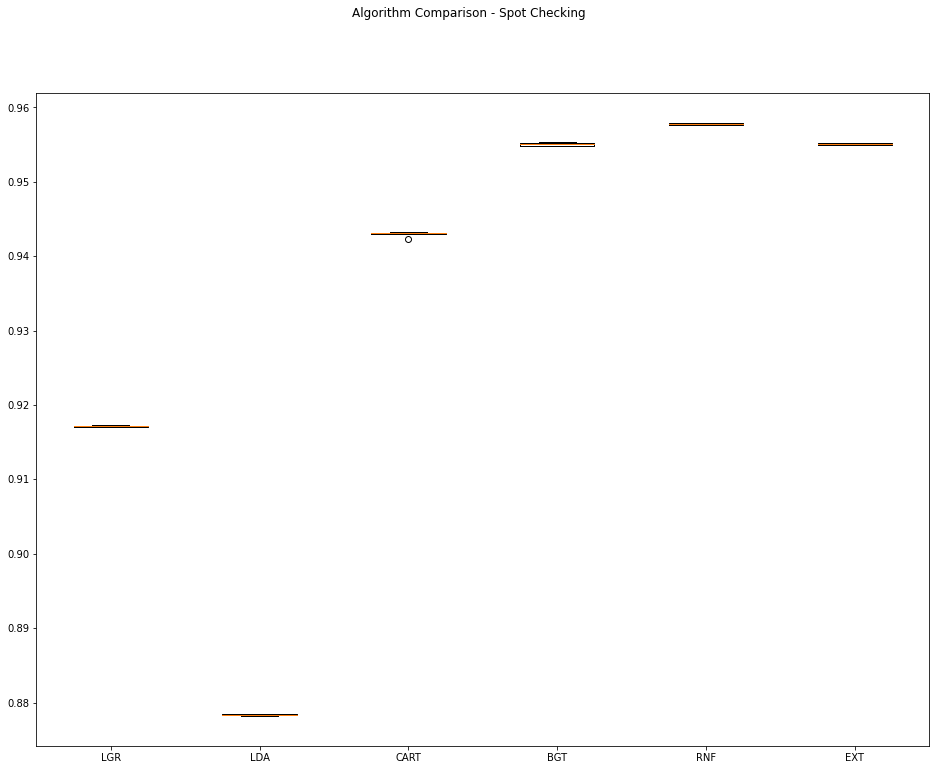

```python
fig = plt.figure(figsize=(16,12))
fig.suptitle('Algorithm Comparison - Spot Checking')
ax = fig.add_subplot(111)
plt.boxplot(train_results)
ax.set_xticklabels(train_model_names)
plt.show()
```

### 4.c) Algorithm Tuning

```python
# Set up the comparison array
tune_results = []
tune_model_names = []
```

```python
# Tuning algorithm #1 - Extra Trees
start_time_mudule = datetime.now()
if NOTIFY_STATUS: status_notify("Algorithm #1 tuning has begun! " + datetime.now().strftime('%a %B %d, %Y %I:%M:%S %p'))

tune_model1 = BaggingClassifier(random_state=RNG_SEED, n_jobs=N_JOBS)
tune_model_names.append('BGT')
paramGrid1 = dict(n_estimators=np.array([10, 20, 30]))

kfold = StratifiedKFold(n_splits=N_FOLDS, shuffle=True, random_state=RNG_SEED)
grid1 = GridSearchCV(estimator=tune_model1, param_grid=paramGrid1, scoring=SCORING_METRIC, cv=kfold, n_jobs=N_JOBS, verbose=1)
grid_result1 = grid1.fit(array_features_train, array_target_train)

print("Best: %f using %s" % (grid_result1.best_score_, grid_result1.best_params_))
tune_results.append(grid_result1.cv_results_['mean_test_score'])
means = grid_result1.cv_results_['mean_test_score']
stds = grid_result1.cv_results_['std_test_score']
params = grid_result1.cv_results_['params']
for mean, stdev, param in zip(means, stds, params):
    print("%f (%f) with: %r" % (mean, stdev, param))
print ('Model training time:',(datetime.now() - start_time_mudule))
if NOTIFY_STATUS: status_notify("Algorithm #1 tuning completed! " + datetime.now().strftime('%a %B %d, %Y %I:%M:%S %p'))
```

```
Fitting 5 folds for each of 3 candidates, totalling 15 fits
Best: 0.957191 using {'n_estimators': 30}
0.955037 (0.000193) with: {'n_estimators': 10}
0.956640 (0.000204) with: {'n_estimators': 20}
0.957191 (0.000176) with: {'n_estimators': 30}
Model training time: 3:49:30.941733
```

```python
best_paramKey1 = list(grid_result1.best_params_.keys())[0]
best_paramValue1 = list(grid_result1.best_params_.values())[0]
print("Captured the best parameter for algorithm #1:", best_paramKey1, '=', best_paramValue1)
```

```
Captured the best parameter for algorithm #1: n_estimators = 30
```

```python
# Tuning algorithm #2 - Random Forest
start_time_mudule = datetime.now()
if NOTIFY_STATUS: status_notify("Algorithm #2 tuning has begun! " + datetime.now().strftime('%a %B %d, %Y %I:%M:%S %p'))

tune_model2 = RandomForestClassifier(random_state=RNG_SEED, n_jobs=N_JOBS)
tune_model_names.append('RNF')
paramGrid2 = dict(n_estimators=np.array([100, 350, 500]))

kfold = StratifiedKFold(n_splits=N_FOLDS, shuffle=True, random_state=RNG_SEED)
grid2 = GridSearchCV(estimator=tune_model2, param_grid=paramGrid2, scoring=SCORING_METRIC, cv=kfold, n_jobs=N_JOBS, verbose=1)
grid_result2 = grid2.fit(array_features_train, array_target_train)

print("Best: %f using %s" % (grid_result2.best_score_, grid_result2.best_params_))
tune_results.append(grid_result2.cv_results_['mean_test_score'])
means = grid_result2.cv_results_['mean_test_score']
stds = grid_result2.cv_results_['std_test_score']
params = grid_result2.cv_results_['params']
for mean, stdev, param in zip(means, stds, params):
    print("%f (%f) with: %r" % (mean, stdev, param))
print ('Model training time:',(datetime.now() - start_time_mudule))
if NOTIFY_STATUS: status_notify("Algorithm #2 tuning completed! " + datetime.now().strftime('%a %B %d, %Y %I:%M:%S %p'))
```

```
Fitting 5 folds for each of 3 candidates, totalling 15 fits
Best: 0.958144 using {'n_estimators': 500}
0.957732 (0.000114) with: {'n_estimators': 100}
0.958068 (0.000090) with: {'n_estimators': 350}
0.958144 (0.000081) with: {'n_estimators': 500}
Model training time: 12:11:13.669826
```

```python
best_paramKey2 = list(grid_result2.best_params_.keys())[0]
best_paramValue2 = list(grid_result2.best_params_.values())[0]
print("Captured the best parameter for algorithm #2:", best_paramKey2, '=', best_paramValue2)
```

```
Captured the best parameter for algorithm #2: n_estimators = 500
```

### 4.d) Compare Algorithms After Tuning

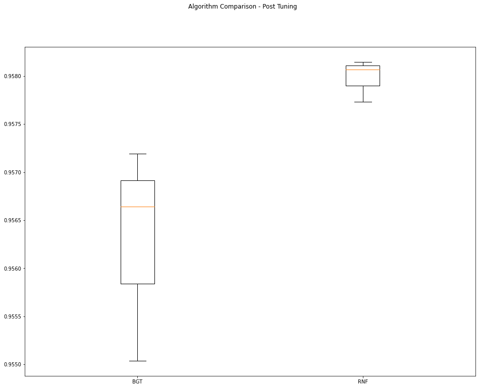

```python
fig = plt.figure(figsize=(16,12))
fig.suptitle('Algorithm Comparison - Post Tuning')
ax = fig.add_subplot(111)
plt.boxplot(tune_results)
ax.set_xticklabels(tune_model_names)
plt.show()
```

```python
if NOTIFY_STATUS: status_notify("Task 4 - Fine-tune and Improve Models completed! " + datetime.now().strftime('%a %B %d, %Y %I:%M:%S %p'))
```

## Task 5 - Finalize Model and Make Predictions

```python
if NOTIFY_STATUS: status_notify("Task 5 - Finalize Model and Make Predictions has begun! " + datetime.now().strftime('%a %B %d, %Y %I:%M:%S %p'))
```

### 5.a) Train the Final Model

```python
final_model = RandomForestClassifier(n_estimators=best_paramValue2, random_state=RNG_SEED, n_jobs=N_JOBS)
final_model.fit(array_features_train, array_target_train)
print(final_model)
```

```
RandomForestClassifier(n_estimators=500, n_jobs=2, random_state=88)
```

### 5.b) Load Test Dataset and Make Predictions

```python
if not os.path.exists(TEST_DATASET):
    !wget https://dainesanalytics.com/datasets/kaggle-tabular-playground-2021dec/test.csv
```

```
--2021-12-20 02:05:25--  https://dainesanalytics.com/datasets/kaggle-tabular-playground-2021dec/test.csv
Resolving dainesanalytics.com (dainesanalytics.com)... 13.225.138.28, 13.225.138.20, 13.225.138.19, ...
Connecting to dainesanalytics.com (dainesanalytics.com)|13.225.138.28|:443... connected.
HTTP request sent, awaiting response... 200 OK
Length: 135209789 (129M) [text/csv]
Saving to: ‘test.csv’

test.csv            100%[===================>] 128.95M  7.03MB/s    in 18s

2021-12-20 02:05:44 (7.03 MB/s) - ‘test.csv’ saved [135209789/135209789]
```

```python
df_features_test = pd.read_csv(TEST_DATASET, index_col=False)

# Take a peek at the dataframe after import
print(df_features_test.head())
```

```
        Id  Elevation  Aspect  Slope  Horizontal_Distance_To_Hydrology  \
0  4000000       2763      78     20                               377
1  4000001       2826     153     11                               264
2  4000002       2948      57     19                                56
3  4000003       2926     119      6                               158
4  4000004       2690      10      4                                38

   Vertical_Distance_To_Hydrology  Horizontal_Distance_To_Roadways  \
0                              88                             3104
1                              39                              295
2                              44                              852
3                             134                             2136
4                             108                             3589

   Hillshade_9am  Hillshade_Noon  Hillshade_3pm  ...  Soil_Type31  \
```

[output cut: 21 more lines]

```python
df_kaggle_submission = pd.DataFrame()
df_kaggle_submission['Id'] = df_features_test['Id']
print(df_kaggle_submission.head())
```

```
        Id
0  4000000
1  4000001
2  4000002
3  4000003
4  4000004
```

```python
# Dropping features
df_features_test.drop(columns=['Id','Soil_Type7','Soil_Type15'], inplace=True)

for feature in float_feature_list:
    df_features_test[feature] = df_features_test[feature].astype('float')

# Take a peek at the dataframe after cleaning
print(df_features_test.head())
```

```
   Elevation  Aspect  Slope  Horizontal_Distance_To_Hydrology  \
0     2763.0    78.0   20.0                             377.0
1     2826.0   153.0   11.0                             264.0
2     2948.0    57.0   19.0                              56.0
3     2926.0   119.0    6.0                             158.0
4     2690.0    10.0    4.0                              38.0

   Vertical_Distance_To_Hydrology  Horizontal_Distance_To_Roadways  \
0                            88.0                           3104.0
1                            39.0                            295.0
2                            44.0                            852.0
3                           134.0                           2136.0
4                           108.0                           3589.0

   Hillshade_9am  Hillshade_Noon  Hillshade_3pm  \
```

[output cut: 28 more lines]

```python
# Finalize the test dataset for the modeling testing
array_features_test = preprocessor.transform(df_features_test)
print("Transformed features from df_features_test.shape: {} to array_features_test.shape: {}".format(df_features_test.shape, array_features_test.shape))
```

```
Transformed features from df_features_test.shape: (1000000, 52) to array_features_test.shape: (1000000, 52)
```

```python
# Make batched predictions
test_predictions = label_encoder.inverse_transform(final_model.predict(array_features_test))
print(test_predictions)
```

```
[2 2 2 ... 2 1 3]
```

```python
df_kaggle_submission['Cover_Type'] = test_predictions
print(df_kaggle_submission.head())
```

```
        Id  Cover_Type
0  4000000           2
1  4000001           2
2  4000002           2
3  4000003           2
4  4000004           2
```

```python
submission_file = df_kaggle_submission.to_csv(header=True, index=False)
filename = 'submission_' + datetime.now().strftime('%Y%m%d-%H%M') + '.csv'
with open(filename, 'w') as f:
    f.write(submission_file)
    print('Completed writing output file: ' + filename)
```

```
Completed writing output file: submission_20211220-0215.csv
```

```python
if NOTIFY_STATUS: status_notify("Task 5 - Finalize Model and Make Predictions completed! " + datetime.now().strftime('%a %B %d, %Y %I:%M:%S %p'))
```

```python
print ('Total time for the script:',(datetime.now() - START_TIME_SCRIPT))
```

```
Total time for the script: 1 day, 11:27:53.866597
```